# PQHS 471 HW1

### 15

```r
library(MASS)
data(Boston)
df=Boston
rsq=function(x){
  r2=summary(x)$r.squared
  return(r2)
}
lmp <- function (modelobject) {
    if (class(modelobject) != "lm") stop("Not an object of class 'lm' ")
    f <- summary(modelobject)$fstatistic
    p <- pf(f[1],f[2],f[3],lower.tail=F)
    attributes(p) <- NULL
    return(p)
}

fmla=lapply(paste("crim", names(df)[-1], sep = "~"), formula)
r2=sapply(fmla,function(x) rsq(lm(x,data=df)))
pvl=sapply(fmla, function(x) lmp(lm(x,data=df)))
which(pvl>0.05)
```

```
## [1] 3
```

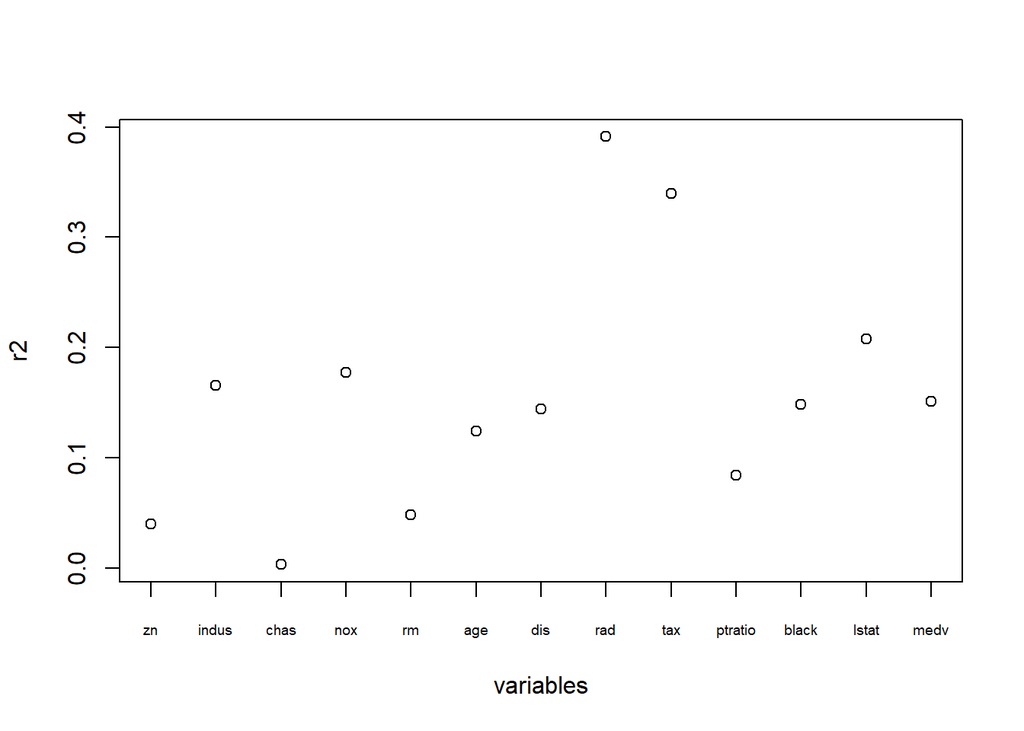

```r
plot(r2, xaxt='n',xlab = 'variables')
axis(1, at=1:13, labels = names(df)[-1], cex.axis = 0.6)
```

The variable chas is not significant.

```r
fit <- lm(crim~., data=df)
summary(fit)
```

```
##
## Call:
## lm(formula = crim ~ ., data = df)
##
## Residuals:
##    Min     1Q Median     3Q    Max
## -9.924 -2.120 -0.353  1.019 75.051
##
## Coefficients:
##               Estimate Std. Error t value
## (Intercept)  17.033228   7.234903   2.354
## zn            0.044855   0.018734   2.394
## indus        -0.063855   0.083407  -0.766
## chas         -0.749134   1.180147  -0.635
## nox         -10.313535   5.275536  -1.955
## rm            0.430131   0.612830   0.702
## age           0.001452   0.017925   0.081
## dis          -0.987176   0.281817  -3.503
## rad           0.588209   0.088049   6.680
## tax          -0.003780   0.005156  -0.733
## ptratio      -0.271081   0.186450  -1.454
## black        -0.007538   0.003673  -2.052
## lstat         0.126211   0.075725   1.667
## medv         -0.198887   0.060516  -3.287
##             Pr(>|t|)
## (Intercept) 0.018949 *
## zn          0.017025 *
## indus       0.444294
## chas        0.525867
## nox         0.051152 .
## rm          0.483089
## age         0.935488
## dis         0.000502 ***
## rad         6.46e-11 ***
## tax         0.463793
## ptratio     0.146611
## black       0.040702 *
## lstat       0.096208 .
## medv        0.001087 **
## ---
## Signif. codes:
## 0 '***' 0.001 '**' 0.01 '*' 0.05 '.' 0.1 ' ' 1
##
## Residual standard error: 6.439 on 492 degrees of freedom
## Multiple R-squared:  0.454,  Adjusted R-squared:  0.4396
## F-statistic: 31.47 on 13 and 492 DF,  p-value: < 2.2e-16
```

For zn, dis, rad, black and medv can we reject the null.

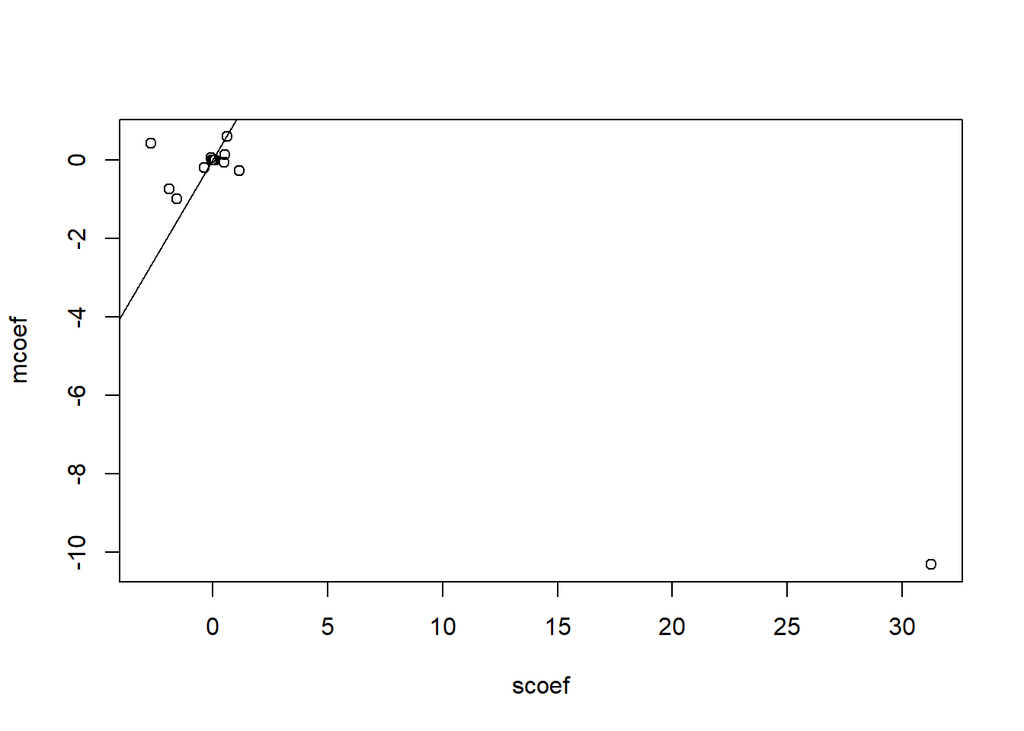

```r
scoef=sapply(fmla,function(x) coef(lm(x,data=df))[2])
mcoef=coef(fit)[-1]
plot(scoef,mcoef)
abline(a=0,b=1)
```

The estimates for nox is very different from simple lm to multiple lm.

```r
summary(lm(crim~poly(zn,3), data=Boston))
```

```
##
## Call:
## lm(formula = crim ~ poly(zn, 3), data = Boston)
##
## Residuals:
##    Min     1Q Median     3Q    Max
## -4.821 -4.614 -1.294  0.473 84.130
##
## Coefficients:
##              Estimate Std. Error t value Pr(>|t|)
## (Intercept)    3.6135     0.3722   9.709  < 2e-16
## poly(zn, 3)1 -38.7498     8.3722  -4.628  4.7e-06
## poly(zn, 3)2  23.9398     8.3722   2.859  0.00442
## poly(zn, 3)3 -10.0719     8.3722  -1.203  0.22954
##
## (Intercept)  ***
## poly(zn, 3)1 ***
## poly(zn, 3)2 **
## poly(zn, 3)3
## ---
## Signif. codes:
## 0 '***' 0.001 '**' 0.01 '*' 0.05 '.' 0.1 ' ' 1
##
## Residual standard error: 8.372 on 502 degrees of freedom
## Multiple R-squared:  0.05824,    Adjusted R-squared:  0.05261
## F-statistic: 10.35 on 3 and 502 DF,  p-value: 1.281e-06
```

```r
summary(lm(crim~poly(indus,3), data=Boston))
```

```
##
## Call:
## lm(formula = crim ~ poly(indus, 3), data = Boston)
##
## Residuals:
##    Min     1Q Median     3Q    Max
## -8.278 -2.514  0.054  0.764 79.713
##
## Coefficients:
##                 Estimate Std. Error t value
## (Intercept)        3.614      0.330  10.950
## poly(indus, 3)1   78.591      7.423  10.587
## poly(indus, 3)2  -24.395      7.423  -3.286
## poly(indus, 3)3  -54.130      7.423  -7.292
##                 Pr(>|t|)
## (Intercept)      < 2e-16 ***
## poly(indus, 3)1  < 2e-16 ***
## poly(indus, 3)2  0.00109 **
## poly(indus, 3)3  1.2e-12 ***
## ---
## Signif. codes:
## 0 '***' 0.001 '**' 0.01 '*' 0.05 '.' 0.1 ' ' 1
##
## Residual standard error: 7.423 on 502 degrees of freedom
## Multiple R-squared:  0.2597, Adjusted R-squared:  0.2552
## F-statistic: 58.69 on 3 and 502 DF,  p-value: < 2.2e-16
```

```r
summary(lm(crim~poly(nox,3), data=Boston))
```

```
##
## Call:
## lm(formula = crim ~ poly(nox, 3), data = Boston)
##
## Residuals:
##    Min     1Q Median     3Q    Max
## -9.110 -2.068 -0.255  0.739 78.302
##
## Coefficients:
##               Estimate Std. Error t value
## (Intercept)     3.6135     0.3216  11.237
## poly(nox, 3)1  81.3720     7.2336  11.249
## poly(nox, 3)2 -28.8286     7.2336  -3.985
## poly(nox, 3)3 -60.3619     7.2336  -8.345
##               Pr(>|t|)
## (Intercept)    < 2e-16 ***
## poly(nox, 3)1  < 2e-16 ***
## poly(nox, 3)2 7.74e-05 ***
## poly(nox, 3)3 6.96e-16 ***
## ---
## Signif. codes:
## 0 '***' 0.001 '**' 0.01 '*' 0.05 '.' 0.1 ' ' 1
##
## Residual standard error: 7.234 on 502 degrees of freedom
## Multiple R-squared:  0.297,  Adjusted R-squared:  0.2928
## F-statistic: 70.69 on 3 and 502 DF,  p-value: < 2.2e-16
```

```r
summary(lm(crim~poly(rm,3), data=Boston))
```

```
##
## Call:
## lm(formula = crim ~ poly(rm, 3), data = Boston)
##
## Residuals:
##     Min      1Q  Median      3Q     Max
## -18.485  -3.468  -2.221  -0.015  87.219
##
## Coefficients:
##              Estimate Std. Error t value Pr(>|t|)
## (Intercept)    3.6135     0.3703   9.758  < 2e-16
## poly(rm, 3)1 -42.3794     8.3297  -5.088 5.13e-07
## poly(rm, 3)2  26.5768     8.3297   3.191  0.00151
## poly(rm, 3)3  -5.5103     8.3297  -0.662  0.50858
##
## (Intercept)  ***
## poly(rm, 3)1 ***
## poly(rm, 3)2 **
## poly(rm, 3)3
## ---
## Signif. codes:
## 0 '***' 0.001 '**' 0.01 '*' 0.05 '.' 0.1 ' ' 1
##
## Residual standard error: 8.33 on 502 degrees of freedom
## Multiple R-squared:  0.06779,    Adjusted R-squared:  0.06222
## F-statistic: 12.17 on 3 and 502 DF,  p-value: 1.067e-07
```

```r
summary(lm(crim~poly(age,3), data=Boston))
```

```
##
## Call:
## lm(formula = crim ~ poly(age, 3), data = Boston)
##
## Residuals:
##    Min     1Q Median     3Q    Max
## -9.762 -2.673 -0.516  0.019 82.842
##
## Coefficients:
##               Estimate Std. Error t value
## (Intercept)     3.6135     0.3485  10.368
## poly(age, 3)1  68.1820     7.8397   8.697
## poly(age, 3)2  37.4845     7.8397   4.781
## poly(age, 3)3  21.3532     7.8397   2.724
##               Pr(>|t|)
## (Intercept)    < 2e-16 ***
## poly(age, 3)1  < 2e-16 ***
## poly(age, 3)2 2.29e-06 ***
## poly(age, 3)3  0.00668 **
## ---
## Signif. codes:
## 0 '***' 0.001 '**' 0.01 '*' 0.05 '.' 0.1 ' ' 1
##
## Residual standard error: 7.84 on 502 degrees of freedom
## Multiple R-squared:  0.1742, Adjusted R-squared:  0.1693
## F-statistic: 35.31 on 3 and 502 DF,  p-value: < 2.2e-16
```

```r
summary(lm(crim~poly(dis,3), data=Boston))
```

```
##
## Call:
## lm(formula = crim ~ poly(dis, 3), data = Boston)
##
## Residuals:
##     Min      1Q  Median      3Q     Max
## -10.757  -2.588   0.031   1.267  76.378
##
## Coefficients:
##               Estimate Std. Error t value
## (Intercept)     3.6135     0.3259  11.087
## poly(dis, 3)1 -73.3886     7.3315 -10.010
## poly(dis, 3)2  56.3730     7.3315   7.689
## poly(dis, 3)3 -42.6219     7.3315  -5.814
##               Pr(>|t|)
## (Intercept)    < 2e-16 ***
## poly(dis, 3)1  < 2e-16 ***
## poly(dis, 3)2 7.87e-14 ***
## poly(dis, 3)3 1.09e-08 ***
## ---
## Signif. codes:
## 0 '***' 0.001 '**' 0.01 '*' 0.05 '.' 0.1 ' ' 1
##
## Residual standard error: 7.331 on 502 degrees of freedom
## Multiple R-squared:  0.2778, Adjusted R-squared:  0.2735
## F-statistic: 64.37 on 3 and 502 DF,  p-value: < 2.2e-16
```

```r
summary(lm(crim~poly(rad,3), data=Boston))
```

```
##
## Call:
## lm(formula = crim ~ poly(rad, 3), data = Boston)
##
## Residuals:
##     Min      1Q  Median      3Q     Max
## -10.381  -0.412  -0.269   0.179  76.217
##
## Coefficients:
##               Estimate Std. Error t value
## (Intercept)     3.6135     0.2971  12.164
## poly(rad, 3)1 120.9074     6.6824  18.093
## poly(rad, 3)2  17.4923     6.6824   2.618
## poly(rad, 3)3   4.6985     6.6824   0.703
##               Pr(>|t|)
## (Intercept)    < 2e-16 ***
## poly(rad, 3)1  < 2e-16 ***
## poly(rad, 3)2  0.00912 **
## poly(rad, 3)3  0.48231
## ---
## Signif. codes:
## 0 '***' 0.001 '**' 0.01 '*' 0.05 '.' 0.1 ' ' 1
##
## Residual standard error: 6.682 on 502 degrees of freedom
## Multiple R-squared:    0.4,  Adjusted R-squared:  0.3965
## F-statistic: 111.6 on 3 and 502 DF,  p-value: < 2.2e-16
```

```r
summary(lm(crim~poly(tax,3), data=Boston))
```

```
##
## Call:
## lm(formula = crim ~ poly(tax, 3), data = Boston)
##
## Residuals:
##     Min      1Q  Median      3Q     Max
## -13.273  -1.389   0.046   0.536  76.950
##
## Coefficients:
##               Estimate Std. Error t value
## (Intercept)     3.6135     0.3047  11.860
## poly(tax, 3)1 112.6458     6.8537  16.436
## poly(tax, 3)2  32.0873     6.8537   4.682
## poly(tax, 3)3  -7.9968     6.8537  -1.167
##               Pr(>|t|)
## (Intercept)    < 2e-16 ***
## poly(tax, 3)1  < 2e-16 ***
## poly(tax, 3)2 3.67e-06 ***
## poly(tax, 3)3    0.244
## ---
## Signif. codes:
## 0 '***' 0.001 '**' 0.01 '*' 0.05 '.' 0.1 ' ' 1
##
## Residual standard error: 6.854 on 502 degrees of freedom
## Multiple R-squared:  0.3689, Adjusted R-squared:  0.3651
## F-statistic:  97.8 on 3 and 502 DF,  p-value: < 2.2e-16
```

```r
summary(lm(crim~poly(ptratio,3), data=Boston))
```

```
##
## Call:
## lm(formula = crim ~ poly(ptratio, 3), data = Boston)
##
## Residuals:
##    Min     1Q Median     3Q    Max
## -6.833 -4.146 -1.655  1.408 82.697
##
## Coefficients:
##                   Estimate Std. Error t value
## (Intercept)          3.614      0.361  10.008
## poly(ptratio, 3)1   56.045      8.122   6.901
## poly(ptratio, 3)2   24.775      8.122   3.050
## poly(ptratio, 3)3  -22.280      8.122  -2.743
##                   Pr(>|t|)
## (Intercept)        < 2e-16 ***
## poly(ptratio, 3)1 1.57e-11 ***
## poly(ptratio, 3)2  0.00241 **
## poly(ptratio, 3)3  0.00630 **
## ---
## Signif. codes:
## 0 '***' 0.001 '**' 0.01 '*' 0.05 '.' 0.1 ' ' 1
##
## Residual standard error: 8.122 on 502 degrees of freedom
## Multiple R-squared:  0.1138, Adjusted R-squared:  0.1085
## F-statistic: 21.48 on 3 and 502 DF,  p-value: 4.171e-13
```

```r
summary(lm(crim~poly(black,3), data=Boston))   # only variable that has neither significant quadratic nor cubic term
```

```
##
## Call:
## lm(formula = crim ~ poly(black, 3), data = Boston)
##
## Residuals:
##     Min      1Q  Median      3Q     Max
## -13.096  -2.343  -2.128  -1.439  86.790
##
## Coefficients:
##                 Estimate Std. Error t value
## (Intercept)       3.6135     0.3536  10.218
## poly(black, 3)1 -74.4312     7.9546  -9.357
## poly(black, 3)2   5.9264     7.9546   0.745
## poly(black, 3)3  -4.8346     7.9546  -0.608
##                 Pr(>|t|)
## (Intercept)       <2e-16 ***
## poly(black, 3)1   <2e-16 ***
## poly(black, 3)2    0.457
## poly(black, 3)3    0.544
## ---
## Signif. codes:
## 0 '***' 0.001 '**' 0.01 '*' 0.05 '.' 0.1 ' ' 1
##
## Residual standard error: 7.955 on 502 degrees of freedom
## Multiple R-squared:  0.1498, Adjusted R-squared:  0.1448
## F-statistic: 29.49 on 3 and 502 DF,  p-value: < 2.2e-16
```

```r
summary(lm(crim~poly(lstat,3), data=Boston))
```

```
##
## Call:
## lm(formula = crim ~ poly(lstat, 3), data = Boston)
##
## Residuals:
##     Min      1Q  Median      3Q     Max
## -15.234  -2.151  -0.486   0.066  83.353
##
## Coefficients:
##                 Estimate Std. Error t value
## (Intercept)       3.6135     0.3392  10.654
## poly(lstat, 3)1  88.0697     7.6294  11.543
## poly(lstat, 3)2  15.8882     7.6294   2.082
## poly(lstat, 3)3 -11.5740     7.6294  -1.517
##                 Pr(>|t|)
## (Intercept)       <2e-16 ***
## poly(lstat, 3)1   <2e-16 ***
## poly(lstat, 3)2   0.0378 *
## poly(lstat, 3)3   0.1299
## ---
## Signif. codes:
## 0 '***' 0.001 '**' 0.01 '*' 0.05 '.' 0.1 ' ' 1
##
## Residual standard error: 7.629 on 502 degrees of freedom
## Multiple R-squared:  0.2179, Adjusted R-squared:  0.2133
## F-statistic: 46.63 on 3 and 502 DF,  p-value: < 2.2e-16
```

```r
summary(lm(crim~poly(medv,3), data=Boston))
```

```
##
## Call:
## lm(formula = crim ~ poly(medv, 3), data = Boston)
##
## Residuals:
##     Min      1Q  Median      3Q     Max
## -24.427  -1.976  -0.437   0.439  73.655
##
## Coefficients:
##                Estimate Std. Error t value
## (Intercept)       3.614      0.292  12.374
## poly(medv, 3)1  -75.058      6.569 -11.426
## poly(medv, 3)2   88.086      6.569  13.409
## poly(medv, 3)3  -48.033      6.569  -7.312
##                Pr(>|t|)
## (Intercept)     < 2e-16 ***
## poly(medv, 3)1  < 2e-16 ***
## poly(medv, 3)2  < 2e-16 ***
## poly(medv, 3)3 1.05e-12 ***
## ---
## Signif. codes:
## 0 '***' 0.001 '**' 0.01 '*' 0.05 '.' 0.1 ' ' 1
##
## Residual standard error: 6.569 on 502 degrees of freedom
## Multiple R-squared:  0.4202, Adjusted R-squared:  0.4167
## F-statistic: 121.3 on 3 and 502 DF,  p-value: < 2.2e-16
```

## ISLR Chapter 4

### 13

```r
library(caret)
library(tidyverse)
set.seed(621)
df$crimcat=ifelse(df$crim > median(df$crim), 1, 0)
dfsplt=createDataPartition(df$crimcat,p=0.7,list = F)
trn=df[dfsplt,]
tst=df[-dfsplt,]
#for logistic regression, choose variables that have high r-squared
fitlog=glm(crimcat~indus+nox+rad+tax+lstat+medv, data=trn, family=binomial)
step(fitlog)
```

```
## Start:  AIC=182.95
## crimcat ~ indus + nox + rad + tax + lstat + medv
##
##         Df Deviance    AIC
## - indus  1   170.19 182.19
## <none>       168.95 182.95
## - lstat  1   172.68 184.68
## - medv   1   172.97 184.97
## - tax    1   178.18 190.18
## - rad    1   210.06 222.06
## - nox    1   242.95 254.95
##
## Step:  AIC=182.19
## crimcat ~ nox + rad + tax + lstat + medv
##
##         Df Deviance    AIC
## <none>       170.19 182.19
## - lstat  1   173.27 183.27
## - medv   1   173.66 183.66
## - tax    1   184.63 194.63
## - rad    1   216.55 226.55
## - nox    1   269.13 279.13
```

```
##
## Call:  glm(formula = crimcat ~ nox + rad + tax + lstat + medv, family = binomial,
##     data = trn)
##
## Coefficients:
## (Intercept)          nox          rad
##  -21.771886    36.224809     0.548376
##         tax        lstat         medv
##   -0.009221     0.079533     0.063170
##
## Degrees of Freedom: 355 Total (i.e. Null);  350 Residual
## Null Deviance:       493.5
## Residual Deviance: 170.2     AIC: 182.2
```

```r
fitlog1=glm(formula = crimcat ~ nox + rad + tax + lstat + medv, family = binomial, data = trn)
logpred=ifelse(predict(fitlog1, tst, type="response")>0.5,1,0)
mean(logpred != tst$crimcat)
```

```
## [1] 0.1333333
```

```r
#LDA
library(MASS)
fitlda=lda(crimcat ~ nox + rad + tax + lstat + medv, data=trn)
ldapred=predict(fitlda, tst)$class
mean(ldapred != tst$crimcat)
```

```
## [1] 0.1666667
```

```r
#QDA
fitqda=qda(crimcat ~ nox + rad + tax + lstat + medv, data=trn)
qdapred=predict(fitqda, tst)$class
mean(qdapred != tst$crimcat)
```

```
## [1] 0.2
```

```r
#KNN
library(DMwR)
knnpred=c()
kk=c(1,5,10,20)
for (i in 1:4)
{
  knnpred[i]=mean(kNN(crimcat ~ nox + rad + tax + lstat + medv, trn,tst,k=kk[i]) != tst$crimcat)
}
knnpred
```

```
## [1] 0.07333333 0.09333333 0.15333333 0.15333333
```

KNN with k=1 gives best prediction in terms of error rate, which is 0.07.

## TITANIC Dataset

My final model is a random forest with formula: Survived ~ Pclass + Sex + SibSp + Parch + Fare, the predicted result is in a separate csv file. The problem with using random forest is that I had to impute the missing values, for Age and Embarked. The latter did not end up in the model though. I generally don’t like to impute, but since I have already used other methods for the homework problem, I thought I’d just try something different. A lot of people online didn’t use random forest I guess due to the fact that imputation is controversial. And some people spent large proportion of their work to perform exploretary data analysis, which is what I’ve been impatient about. But as far as my experience with large datasets goes, I started to realize how important the preliminary work would be.